# Homework-2023.11.13

By SA23229026

2023/11/13

# 2023/09/11

## Question

使用Knitr生成三个例子，每个例子需要包含文本以及图片或表格，附带一些公式。

## Answer

### Example 1

鸢尾花数据集是分类方法文献中最早使用的数据集之一，并广泛用于统计和机器学习。该数据集包含3个类，每个类有50个实例，每个类代表一种鸢尾花。下面查看一下鸢尾花数据集的详细信息：

```r
data <- iris
summary(data)
```

```
##   Sepal.Length    Sepal.Width     Petal.Length    Petal.Width
##  Min.   :4.300   Min.   :2.000   Min.   :1.000   Min.   :0.100
##  1st Qu.:5.100   1st Qu.:2.800   1st Qu.:1.600   1st Qu.:0.300
##  Median :5.800   Median :3.000   Median :4.350   Median :1.300
##  Mean   :5.843   Mean   :3.057   Mean   :3.758   Mean   :1.199
##  3rd Qu.:6.400   3rd Qu.:3.300   3rd Qu.:5.100   3rd Qu.:1.800
##  Max.   :7.900   Max.   :4.400   Max.   :6.900   Max.   :2.500
##        Species
##  setosa    :50
##  versicolor:50
##  virginica :50
##
##
##
```

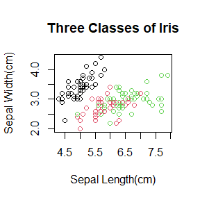

```r
# par(pin=c(3,2))
plot(data$Sepal.Length, data$Sepal.Width, col=data$Species, xlab = "Sepal Length(cm)", ylab = "Sepal Width(cm)", main="Three Classes of Iris")
```

### Example 2

线性回归是一种通过线性模型来拟合样本的属性与标记的方法。对于数据集$D = \{(x_1,y_1),(x_2,y_2),\ldots,(x_n,y_n)\}$，线性回归希望得到

$$f(x_i) = wx_i+b,其中f(x_i) \simeq y_i.$$

确定$w$和$b$的方式就是最小化如下的损失函数

$$L(w,b)= \sum_{i=1}^n(f(x_i)-y_i)^2$$
下面对一组身高体重数据集进行回归

| Height | Weight |
| --- | --- |
| 151 | 63 |
| 174 | 81 |
| 138 | 56 |
| 186 | 91 |
| 128 | 47 |
| 136 | 57 |
| 179 | 76 |
| 163 | 72 |
| 152 | 62 |
| 131 | 48 |

最终得到的线性回归模型如图所示

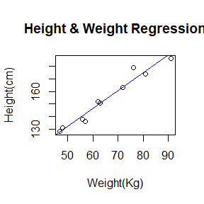

### Example 3

K-means是一种常用的聚类算法，它的算法步骤为：

1. 初始化：选择初始化的k个样本作为初始的中心；
2. 迭代：
- 对于每个样本，计算它到k个中心的距离，并把它划分到距离最小的中心所对应的类中；
- 对于每个类，重新计算中心。
3. 当每个样本所属的类不再发生改变时定制迭代。

下面随机生成100个样本：

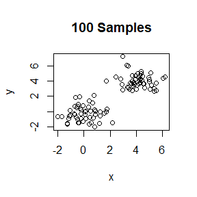

聚类结果如下

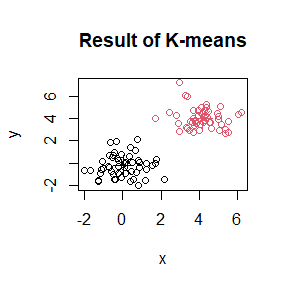

# 2023/09/18

## Question

1. 使用逆变换方法实现函数`sample()`的部分功能，其中参数`replace=TRUE`。
2. 标准Laplace分布的密度函数为$f(s) = \frac{1}{2}e^{-\vert x \vert}$，$x\in \mathbb{R}$。使用逆变换生成1000次这个分布的采样，并将生成的采样和目标分布进行比较。
3. 使用acceptance-rejection method写一个函数，从$Beta(a, b)$分布中随机采样n次。举例从$Beta(3, 2)$中随机采样1000次。画出采样的 直方图，并在上面加上$Beta(3,2)$的概率密度函数。
4. 生成密度函数
   $$f_e(x) = \frac{3}{4}(1-x^2), \quad \vert x \vert \le1.$$
   使用如下算法：生成iid的$U_1,U_2,U_3~U(-1, 1)$。如果$\vert U_3 \vert \geq \vert U_2 \vert$并且$\vert U_3 \vert \geq \vert U_1 \vert$，则取$\vert U_2 \vert$；否则取$\vert U_3 \vert$。写一个函数生成$f_e$的随机变量，并画直方图。
5. 证明上一问中的算法。

## Answer

### 1 逆变换复现`sample()`

**Usage**

`Mysample(x, size, prob=Null)`

**Description**

`Mysample`从区间`x`中有放回地采样个数为`size`的样本。

`x`：采样区间；

`size`：采样个数。

`prob`：概率，默认等概率，可以输入想要的概率。

函数定义如下

```r
Mysample <- function(x, size, prob=NULL){
  n <- length(x) # 获取区间x中的元素个数
  if (is.null(prob)) {
    p <- rep(1/n, n) # 如果prob为空，所有样本概率相同
  }
  cp <- cumsum(prob)
  U <- runif(size)
  r <- x[findInterval(U, cp)+1]
  return(r)
}
```

**Examples**

从{0，1}中采样10次

```r
Mysample(0:1, 10)
```

```
##  [1] 0 0 0 0 0 0 0 0 0 0
```

从{2,5,8,9}中采样1000次

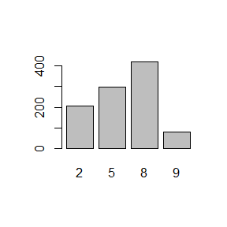

```r
r <- Mysample(c(2, 5, 8, 9), 1000, prob = c(.2, .3, .4, .1))
barplot(table(r))
```

### 2 标准Laplace分布

标准Laplace分布的概率密度函数$f(x) = \frac{1}{2}e^{-\vert x \vert}$，可以得到其分布函数为

$$F_X(x) =
\begin{cases}
\frac{1}{2}e^x & \text{if } x \leq 0 \\
1-\frac{1}{2}e^{-x} & \text{if } x > 0
\end{cases}$$
求其逆函数可以得到

$$F_X^{-1}(u) =
\begin{cases}
\log{2u} & \text{if } u \leq \frac{1}{2} \\
-\log{2(1-u)} & \text{if } u > \frac{1}{2}
\end{cases}$$

这个分段函数可以用一个符号函数$sign()$合并

$$F_X^{-1}(u) = sign(\frac{1}{2}-u)log(1-\vert 2u-1 \vert)$$

编程实现如下，并用直方图和原分布做比较

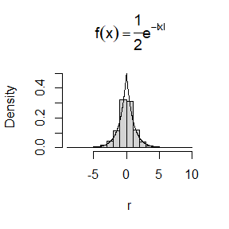

```r
n <- 1e4
u <- runif(n)
r = sign(0.5-u)*log(1-abs(2*u-1))
hist(r, prob=TRUE, ylim=c(0, 0.55), main=expression(f(x)==frac(1,2)*e^-abs(x)))
y <- seq(-5, 5, .01)
lines(y, 0.5*exp(-abs(y)))
```

### 3 Beta分布

$Beta(a, b)$分布的概率密度函数为$f(x; a, b) = \frac{x^{a - 1} (1 - x)^{b - 1}}{B(a, b)}$。另$g(x)～U(0,1)$。可以直接另$c=\frac{1}{B(a,b)}$，但这不是$c$的最小取值，为找到$c$的最小取值，可以通过求$f (x;a,b)$的最大值得到。由于$f(x;a,b)$在$(0,1)$上只有一个极值点，且是极大值点，所以直接求其极值点即可。

$$\frac{df}{dx}=\frac{1}{B(a,b)}[(a-1)x^{a-2}(1-x)^{b-1}-(b-1)x^{a-1}(1-x)^{b-2}]=0
\\
x = \frac{a-1}{a+b-2}$$
所以当$x= \frac{a-1}{a+b-2}$时，可以得到最大值$f_{max}(x;a,b)=\frac{1}{B(a,b)}(\frac{a-1}{a+b-2})^{a-1}(1-\frac{a-1}{a+b-2})^{b-1}$，另$c=f_{max}(x;a,b)$可以使计算效率最高。

下面给出用acceptance-rejection method进行Beta分布采样的函数

```r
myBeta <- function(a, b, n){
  t = (a-1)/(a+b-2)
  c = 1/beta(a, b)*t**(a-1)*(1-t)**(b-1)
  k <- 0
  j <- 0
  y <- numeric(n)
  while(k<n){
    u1 <- runif(1)
    u2 <- runif(1)
    j <- j + 1
    if (dbeta(u2, a, b) > u1){
      k <- k+1
      y[k] <- u2
    }
  }
  out <- list(y = y, j = j, c = c)
  return(out)
}
```

下面对$Beta(3,2)$进行1000次采样，并绘制直方图

```r
out = myBeta(3, 2, 1000)
cat("iterations: ", out$j)
```

```
## iterations:  1353
```

采样1000个变量总共只迭代了这么多次，效率很高。

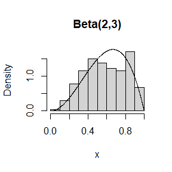

```r
x <- out$y
hist(x, prob=TRUE, ylim=c(0, out$c), main="Beta(2,3)")
y <- seq(0, 1, .001)
lines(y, dbeta(y, 3, 2))
```

### 3 $f_e$

算法编程如下

```r
myfe <- function(n){
  k <- 0
  y <- numeric(n)
  while(k<n){
    u1 <- runif(1, -1, 1)
    u2 <- runif(1, -1, 1)
    u3 <- runif(1, -1, 1)
    if ((abs(u3)>abs(u2) || abs(u3)== abs(u2)) && (abs(u3)>abs(u1) || abs(u3)== abs(u1))){
      k <- k + 1
      y[k] <- u2
    } else {
      k <- k + 1
      y[k] <- u3
    }
  }
  return(y)
}
```

采样100000次，结果的直方图和原密度函数比较如下

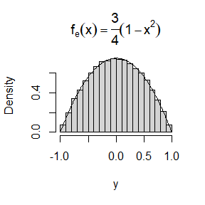

```r
y <- myfe(1e5)
hist(y, prob = TRUE, main=expression(f[e](x)==frac(3,4)(1-x^2)))
x<- seq(-1, 1, .01)
lines(x, 0.75 * (1 - x**2))
```

### 5 证明算法

要证明该算法，只需证明该算法得到的概率分布函数和原概率分布函数相同即可。

原概率分布函数为

$$F_X(x)=\int_{-1}^{x}\frac{3}{4}(1-x^2)dx=-\frac{1}{4}x^3+\frac{3}{4}x+\frac{1}{2}$$
下面计算由该算法得到分布函数，由算法可以得到，分布函数可以分为两部分
$$\begin{align}
F_U(x)&=P(U\leq x)\\
&=P(U_2\leq x|U=U_2)P(U=U_2)+P(U_3\leq x|U=U_3)P(U=U_3)\\
&=P(U_2\leq x,U=U_2)+P(U_3\leq x,U=U_3)
\end{align}$$
记$F_1(x) =P(U_2\leq x,U=U_2),F_2(x)= P(U_3\leq x,U=U_3)$，分别进行计算。由于$U_1, U_2,U_3$是iid的，所以可以得到
$$f(u_1, u_2, u_3) =f(u_1)f(u_2)f(u_3)$$

首先计算$-1\leq x <0$时的情况

$$\begin{align}
F_1(x) &= \int_{-1}^{x}\int_{u_3}^{x}\int_{u_3}^{-u_3}
f(u_1)f(u_2)f(u_3)du_1du_2du_3
+\int_{-x}^{1}\int_{-u_3}^{x}\int_{-u_3}^{u_3}
f(u_1)f(u_2)f(u_3)du_1du_2du_3\\
&=-\frac{1}{12}x^3+\frac{1}{4}x+\frac{1}{6}
\end{align}$$
$$\begin{align}
F_2(x)&=
4[\int_{-1}^{x}\int_{-1}^{u_3}f(u_1)f(u_3)du_1du_3]-4[\int_{-1}^{x}\int_{-1}^{u_3}\int_{-1}^{u_3}
f(u_1)f(u_2)f(u_3)du_1du_2du_3]\\
&=-\frac{1}{6}x^3+\frac{1}{2}x+\frac{1}{3}
\end{align}$$
因此可以得到，当$-1\leq x <0$时，有
$$F_U(x)=F_1(x)+F_2(x)=-\frac{1}{4}x^3+\frac{3}{4}x+\frac{1}{2}=F_X(x)$$
通过计算可以得到，$0\leq x \leq 1$的情况与$-1\leq x <0$是对称的，也有
$$F_U(x)=F_X(x)$$
得证。

# 2023/09/25

## Question

1. 证明当$\rho =\frac{l}{d}$取何值时，$\hat{\pi}$的渐进方差最小? ($m ∼ B(n,p)$, 使用$\delta$法)
2. 取三个不同的$\rho$值($0 \leq \rho \leq 1$, 包含$\rho_{min}$)然后使用Monte Carlo模拟来验证你的答案。 ($n = 10^6$, 重复模拟次数$K = 100$)
3. 在例子5.7中， 举了下面一个Monte Carlo积分的例子来说明control variate逼近方法
   $$\theta = \int_0^1 e^xdx.$$
   现在考虑使用antithetic variate逼近。计算$Cov(e^U,e^{1−U})$和$Var(e^U + e^{1−U})$，其中$U$∼Uniform(0,1)。使用antithetic variate逼近可以让$\hat{\theta}$的方差下降百分之多少（与简单的MC相比）？
4. 联系上一问。使用Monte Carlo模拟来估计$\theta$，分别通过antithetic variate逼近和简单的Monte Carlo模拟方法。计算使用antithetic variate时， 方差减少百分比的经验估计。将结果与上一问中的理论值相比较。

## Answer

### 1

证明. 首先，我们有概率$p$的表达式

$$p = \frac{2l}{\pi d}=\frac{2\rho}{\pi}.$$

通过$\hat{p} = m/n$可以得到随机变量$\hat{\pi}$与随机变量$m$之间的关系为

$$\hat{\pi} = \frac{2\rho}{\hat{p}}=\frac{2\rho n}{m}=f(m).$$
由于$m$~$B(n,p)$，我们可以得到

$$\mu = E(m) = np,\\
\sigma^2= D(m) = np(1-p).$$

根据$\delta$法，可以得到$\hat{\pi}$的近似方差为

$$\begin{align}
D(\hat{\pi}) & \approx [f'(\mu)]^2\sigma^2\\
&=\frac{4\rho^2n^2}{n^4p^4}np(1-p)\\
&=\frac{4\rho^2(1-p)}{np^3},
\end{align}$$

代入$p = \frac{2l}{\pi d}$可以得到

$$D(\hat{\pi}) \approx \frac{\pi^3}{2n}(\frac{1}{\rho}-\frac{2}{\pi}).$$

当$0\leq \rho \leq 1$时，该式关于$\rho$是递减的，所以$\rho_{min}=1$时，$\hat{\pi}$的渐进方差最小。

### 2

分别取$\rho = 0.5$，$\rho = 0.8$和$\rho = 1$，计算$\hat{\pi}$的方差。

```r
n <- 10^6 # 试验次数
K <- 100 # 模拟次数
rhos <- c(0.5, 0.8, 1) # rho的取值
for (rho in rhos){
  m <- rbinom(K, n, 2*rho/pi) # 以2*rho/pi的概率生成随机数
  pi_hat <- 2*rho*n/m # 计算pi_hat
  D = var(pi_hat) # 计算方差
  cat("rho =", rho,"    variance =", D, "\n")
}
```

```
## rho = 0.5     variance = 2.237451e-05
## rho = 0.8     variance = 1.080282e-05
## rho = 1     variance = 4.421879e-06
```

可以看到，当$\rho = 1$时的方差时最小的。

### 3

先计算$Cov(e^U,e^{1-U})$，

$$\begin{align}
Cov(e^U,e^{1-U}) &= E(e^Ue^{1-U})-E(e^U)E(e^{1-U}) \\
& = e - (e-1)^2 .
\end{align}$$

下面计算$Var(e^U+e^{1-U})$，

$$Var(e^U) = E(e^{2U}) - [E(e^U)]^2 = \frac{e^2-1}{2}-(e-1)^2,$$

$$\begin{align}
Var(e^{1-U}) &= E(e^{2-2U}) - [E(e^{1-U})]^2\\
& = -\frac{1-e^2}{2}-(e-1)^2,
\end{align}$$

$$\begin{align}
Var(e^U+e^{1-U})& = Var(e^U)+Var(e^{1-U})+Cov(e^U,e^{1-U}) \\
& = \frac{e^2-1}{2}-(e-1)^2-\frac{1-e^2}{2}-(e-1)^2+2e -
2(e-1)^2 \\
&= -3e^2+10e-5.
\end{align}$$

下面来计算方差减少的百分比

$$Var(\hat{\theta}) = \frac{1}{m}Var(e^U),\\
\hat{\theta}' = \frac{1}{m}\sum_{j=1}^{m/2}(e^{U_j}+e^{1-U_j}),\\
Var(\hat{\theta}') = \frac{1}{2m}Var(e^U+e^{1-U}).$$

所以

$$1-\frac{Var(\hat{\theta}')}{Var(\hat{\theta})} =
1-\frac{\frac{1}{2}(-3e^2+10e-5)}{\frac{e^2-1}{2}-(e-1)^2} = 0.9676701,$$

因此使用antithetic variate逼近可以让$\hat{\theta}$的方差下降96.77%。

### 4

分别通过antithetic variate逼近和简单的Monte Carlo模拟方法来估计$\theta$，模拟$10^6$次，每次采样100次。

```r
K = 10^6 # 模拟次数
n = 100 # 采样次数
MC1 = numeric(K)
MC2 = numeric(K)
for (i in 1:K){
  u = runif(n/2)
  v = runif(n/2)
  MC1[i] = mean(exp(c(u,v)))
  MC2[i] = mean(exp(c(u, 1-u)))
}
theta1 = mean(MC1)
theta2 = mean(MC2)
var1 = var(MC1)
var2 = var(MC2)
cat("theta1:",theta1,"\ntheta2:",theta2,"\nvariance reduction:", 1-var2/var1)
```

```
## theta1: 1.718265
## theta2: 1.718293
## variance reduction: 0.9676486
```

两种方法模拟估计的$\hat{\theta}$都和真实值接近，方差减少的百分比和上一问得到的理论值非常接近。

# 2023/10/09

## Question

$Var(\hat{\theta}{}^M)= \frac{1}{Mk}\sum_{i=1}^{k}\sigma_i^2+\frac{1}{M}Var(\theta_I)=Var(\hat{\theta}{}^S)+\frac{1}{M}Var(\theta_I)$, where $\theta_i = E[g(U)|I=i]$, $\sigma_i^2 = Var[g(U)|I=i]$ and $I$ takes uniform distribution over ${1,\ldots,k}$.

Proof that if $g$ is a continuous function over $a, b$, then $Var(\hat{\theta}{}^S)/Var(\hat{\theta}{}^M) \to 0$ as $b_i-a_i \to 0$ for all $i=1,\ldots,k$.

- Exercises 5.13, 5.14, 5.15 (pages 149-151, Statistical Computing with R).
- Exercises 6.5, 6.A (pages 180-181, Statistical Computing with R).

## Answer

### 1

证明.

$$\begin{aligned}
\frac{Var(\hat{\theta}{}^S)}{Var(\hat{\theta}{}^M)} & =
\frac{\frac{1}{Mk}\sum_{i=1}^{k}\sigma_i^2}{\frac{1}{Mk}\sum_{i=1}^{k}\sigma_i^2+\frac{1}{M}Var(\theta_I)}\\
&=\frac{1}{1+
\frac{Var(\theta_I)}{\frac{1}{k}\sum_{i=1}^{k}\sigma_i^2}},
\end{aligned}$$
当$b_i-a_i \to 0$时，$\theta_I \to g(U)$，则$Var(\theta_i) \to Var(g(U))$。由于$g$是连续的，可以得到$Var(g(U))<\infty$。下面再看分母$\frac{1}{k}\sum_{i=1}^{k}\sigma_i^2$,将其写成积分的形式

$$\begin{aligned}
\frac{1}{k}\sum_{i=1}^{k}\sigma_i^2 &= \frac{1}{k}\sum_{i=1}^{k}
\int_{a_i}^{b_i}[g(u)-\theta_i]^2\frac{1}{b_i-a_i}du.
\end{aligned}$$

我们令

$$d_i = g_{max}(u)-g_{min}(u),\\
u \in [a_i, b_i],$$

显然，$[g(u)-\theta_i]^2 \leq d_i^2$，所以

$$\begin{aligned}
\frac{1}{k}\sum_{i=1}^{k}\sigma_i^2 & < \frac{1}{k}\sum_{i=1}^{k}
\int_{a_i}^{b_i}d_i^2\frac{1}{b_i-a_i}du\\
& = \frac{1}{k}\sum_{i=1}^{k} (b_i-a_i)d_i^2\frac{1}{b_i-a_i}\\
& =\frac{1}{k}\sum_{i=1}^{k}d_i^2,
\end{aligned}$$

我们令

$$d_{max} = \max_i{d_i}, \qquad
i = 1, 2, \ldots, k,$$
可以得到

$$\frac{1}{k}\sum_{i=1}^{k}\sigma_i^2<\frac{1}{k}\sum_{i=1}^{k}d_i^2<\frac{1}{k}kd_{max}^2
= d_{max}^2$$

由于$g$是连续的，当$b_i-a_i \to 0$时，$d_{max}^2 \to 0$,即

$$\frac{1}{k}\sum_{i=1}^{k}\sigma_i^2 \to 0 \quad (b_i-a_i \to 0).$$

综上，可以得到

$$\frac{Var(\hat{\theta}{}^S)}{Var(\hat{\theta}{}^M)} =\frac{1}{1+
\frac{Var(\theta_I)}{\frac{1}{k}\sum_{i=1}^{k}\sigma_i^2}} \to 0 \quad
(b_i-a_i \to 0).$$

得证。

### 5.13

两个重要性函数分别为

$$f_1(x) = \frac{1}{\sqrt{2\pi}}e^{-\frac{x^2}{2}},\\
f_2(x) = e^{-x}.$$

使用Monte Carlo方法来估计方差

```r
m <- 1e4
theta.hat <- var.hat <- numeric(2)
g <- function(x){
  x^2/sqrt(2*pi)*exp(-x^2/2)*(x>1)
}

x <- rnorm(m) # f1
fg <- g(x) / dnorm(x)
theta.hat[1] <- mean(fg)
var.hat[1] <- var(fg)

x <- rexp(m, 1) # f2
fg <- g(x) * exp(x)
theta.hat[2] <- mean(fg)
var.hat[2] <- var(fg)

rbind(theta.hat, var.hat)
```

```
##               [,1]      [,2]
## theta.hat 0.390903 0.4043807
## var.hat   1.252159 0.3456249
```

通过Monte Carlo模拟，可以看到使用$f_2$进行重要性采样的方差更小。

### 5.14

使用如下函数来进行重要性采样

$$f(x) = \frac{1}{\sqrt{2\pi}}e^{-\frac{(x-1.5)^2}{2}}$$

```r
m <- 1e4
g <- function(x){
  x^2/sqrt(2*pi)*exp(-x^2/2)*(x>1)
}

x <- rnorm(m, mean=1.5) # 设置正太分布的均值为1.5
fg <- g(x) / dnorm(x, mean=1.5)
theta.hat <- mean(fg)
se <- sd(fg)

rbind(theta.hat, se)
```

```
##                [,1]
## theta.hat 0.4024334
## se        0.3017844
```

最终得到该积分的估计值$\hat{\theta}$=0.4024334，估计标准差为0.3017844。

### 5.15

```r
M <- 10000 # 总采样次数
k <- 5 # 层数
E <- numeric(k) # 保存每次中每层的均值
N = 50 # 估计次数
r <- M/k/N
est = numeric(N) # 保存每次估计的均值

g<-function(x){
  exp(-x)/(1+x^2)*(x>0)*(x<1)
}

for(i in 1:N){
  for(j in 1:k){
    E[j]<-mean(g(runif(r,(j-1)/k,j/k)))
  }
  est[i] = mean(E)
}
theta.hat = mean(est)
se = sd(est)

rbind(theta.hat, se)
```

```
##                  [,1]
## theta.hat 0.524700753
## se        0.003486331
```

最终得到估计值$\hat{\theta}$=0.5247008，估计标准差为0.0034863。而Example5.10中最小的估计标准差为0.097，分层采样很容易就得到了更小的标准差。

### 6.5

令

$$P(a\leq \frac{\sqrt{n}(\bar{X}-\mu)}{S}\leq b)=1-\alpha,\\
\frac{\sqrt{n}(\bar{X}-\mu)}{S}~t(n-1),$$

可以得到均值$\mu$的双侧$1-\alpha$置信区间为

$$[\bar{X}-t_{1-\frac{\alpha}{2}}\frac{S}{\sqrt{n}},\bar{X}+t_{1-\frac{\alpha}{2}}\frac{S}{\sqrt{n}}].$$
下面从分布$\chi^2(2)$中随机采样，并用Monte Carlo实验来估计t-置信区间的覆盖率。

```r
n <- 20
alpha <- .05
calcCI <- function(n, alpha){
  y <- rchisq(n, df = 2)
  return(c(mean(y)-qt(1-alpha/2, df=n-1)*sd(y)/sqrt(n), mean(y)+qt(1-alpha/2, df=n-1)*sd(y)/sqrt(n)))
}

CL <- replicate(1000, expr = calcCI(n=n, alpha=alpha))
rate = mean((CL[1,]<2)*(CL[2,]>2))
print(rate)
```

```
## [1] 0.926
```

最终得到置信区间的覆盖率为92.6%。和Example6.4相比，在分布$\chi^2(2)$中随机采样时，直接使用正态分布的置信区间，对均值的覆盖率会偏小。

### 6.A

```r
n <- 20
alpha <- .05
mu0 <- 1

m <- 10000
p <- matrix(0, 3, m)

for (j in 1:m) {
  x <- rchisq(n, df=1) # X^2(1)
  ttest <- t.test(x, alternative = "two.sided", mu = mu0)
  p[1, ] <- ttest$p.value

  x <- runif(n, 0, 2) # U(0, 2)
  ttest <- t.test(x, alternative = "two.sided", mu = mu0)
  p[2, ] <- ttest$p.value

  x <- rexp(n, 1) # Exponential(1)
  ttest <- t.test(x, alternative = "two.sided", mu = mu0)
  p[3, ] <- ttest$p.value
}

p.hat <- apply(p<alpha, 1, mean)
se.hat <- sqrt(p.hat * (1 - p.hat) / m)
table = data.frame(
  p.hat = p.hat,
  se.hat = se.hat,
  row.names=c("X^2(1)", "U(0, 2)", "Exponential(1)")
)
print(table)
```

```
##                p.hat se.hat
## X^2(1)             0      0
## U(0, 2)            0      0
## Exponential(1)     0      0
```

总共进行了10000次双侧t检验，每次分别从3个分布中随机采样20个样本。在$\alpha$=0.05的情况下，$\chi^2(1)$，$Uniform(0,2)$和$Exponential(1)$全部接受原假设$H_0$。$\chi^2(1)$、$Uniform(0,2)$和$Exponential(1)$的经验$T1e$比例为0%，标准差为0。

# 2023/10/16

## Question

1. 考虑$m=1000$个假设，其中前95%个原假设成立，后5%个对立假设成立。在原假设之下，p值服从U(0,1)分布，在对立假设之下，p值服从Beta(0.1, 1)分布（可用rbeta生成）。应用Bonferroni校正与B-H校正应用于生成的m个p值（独立）（应用p.adjust），得到校正后的p值，与$\alpha$=0.1比较确定是否拒绝原假设。基于M=1000次模拟，可估计FWER，FDR，TPR输出到表格中。
2. Suppose the population has the exponential distribution with rate $\lambda$, then the MLE of $\lambda$ is $\hat{\lambda}=1/\bar{X}$, where $\bar{X}$ is the sample mean. It can be derived that the expectation of $\hat{\lambda}$ is $\lambda n/(n-1)$, so that the estimation bias is $\lambda/(n-1)$. The standard error $\hat{\lambda}$ is $\lambda n/[(n-1)\sqrt{n-2}]$. Conduct a simulation study to verify the performance of the boostrap method.
- The true value of $\lambda$=2.
- The sample size n=51020.
- The number of bootstrap replicates B=1000.
- The simulations are repeated for m=1000 times.
- Compare the mean bootstrap bias and bootstrap standard error with the theoretical ones. Comment on the results.
3. Exercises 7.3 (pages 212, Statistical Computing with R).

## Answer

### 1

```r
M = 1000
m = 1000
alpha = 0.1

result_bfn <- result_bh <- matrix(0,M,3)

for (i in 1:M){
  set.seed(1000+i)
  # 对立假设成立为1， 原假设成立为0
  # 拒绝原假设为1，不拒绝原假设为0
  label_true <- c(rep(FALSE, 0.95*m), rep(TRUE, 0.05*m))
  p = c(runif(0.95*m, 0, 1), rbeta(0.05*m, 0.1, 1))

  # 校正
  p.bfn = p.adjust(p,method='bonferroni')
  p.bh = p.adjust(p,method='BH')
  # 获取检验结果
  label_bfn <- p.bfn < alpha
  label_bh <- p.bh < alpha
  # 构造混淆矩阵
  confusion_bfn <- table(Predicted = label_bfn, Actual = label_true)
  confusion_bh <- table(Predicted = label_bh, Actual = label_true)
  result_bfn[i, ] <- c(confusion_bfn[2,1]>0, confusion_bfn[2,1]/sum(confusion_bfn[2, ]), confusion_bh[2,2]/sum(confusion_bfn[, 2]))
  result_bh[i, ] <- c(confusion_bh[2,1]>0, confusion_bh[2,1]/sum(confusion_bh[2, ]), confusion_bh[2,2]/sum(confusion_bh[, 2]))
}

table = data.frame(
  Bonferroni = colMeans(result_bfn),
  B.H = colMeans(result_bh),
  row.names = c("FWER", "FDR", "TPR")
)

print(t(table))
```

```
##             FWER         FDR     TPR
## Bonferroni 0.102 0.005064083 0.56608
## B.H        0.934 0.095595186 0.56608
```

### 2

```r
library(boot)
sample_size = c(5, 10, 20) # 采样个数
B = 1000 # bootstrap重复次数
m = 1000 # 模拟次数

# 计算lambda的估计值
b.lambda <- function(x, i){
  1/mean(x[i])
}

total = matrix(0, 3, 2) # 记录bootstrap估计值
for (i in 1:3){
  n = sample_size[i]
  matrix_temp = matrix(0, 1000, 2)
  for (m in 1:1000){
    x = rexp(n, 2)
    obj <- boot(data=x, statistic = b.lambda, R=1000)
    matrix_temp[m, ] <- c(mean(obj$t)-obj$t0, sd(obj$t))
  }
  total[i, ] <- colMeans(matrix_temp)
}

table = data.frame(
  bias.bootstrap = total[, 1],
  bias.theoretical = 2/(sample_size-1),
  se.bootstrap = total[, 2],
  se.theoretical = 2*sample_size/((sample_size-1)*sqrt(sample_size-2)),
  row.names = sample_size
)
print(table)
```

```
##    bias.bootstrap bias.theoretical se.bootstrap se.theoretical
## 5       0.5841660        0.5000000    2.1742886      1.4433757
## 10      0.2161053        0.2222222    0.8035989      0.7856742
## 20      0.1052854        0.1052632    0.5091069      0.4962153
```

可以看到bootstrap得到的估计值随着采样个数的增加，和理论值越来越接近。

### 3

```r
library(bootstrap)
library(boot)

boot.t.ci <- function(x, B = 500, R = 100, level = .95, statistic){
  # 计算bootstrap的t置信区间
  x <- as.matrix(x); n <- nrow(x)
  stat <- numeric(B); se <- numeric(B)
  boot.se <- function(x, R, f) {
    #计算bootstrap的估计标准差，f是统计量
    x <- as.matrix(x); m <- nrow(x)
    th <- replicate(R, expr = {
    i <- sample(1:m, size = m, replace = TRUE)
    f(x[i, ])
    })
    return(sd(th))
  }
  for (b in 1:B) {
    j <- sample(1:n, size = n, replace = TRUE)
    y <- x[j, ]
    stat[b] <- statistic(y)
    se[b] <- boot.se(y, R = R, f = statistic)
  }
  stat0 <- statistic(x)
  t.stats <- (stat - stat0) / se
  se0 <- sd(stat)
  alpha <- 1 - level
  Qt <- quantile(t.stats, c(alpha/2, 1-alpha/2), type = 1)
  names(Qt) <- rev(names(Qt))
  CI <- rev(stat0 - Qt * se0)
}

dat <- law # 导入数据

stat <- function(dat) {
  # 计算相关性的统计量
  cor(dat[,1], dat[,2])
}

ci <- boot.t.ci(dat, statistic = stat, B = 2000, R = 200)

print(ci)
```

```
##        2.5%       97.5%
## -0.09913269  0.97047524
```

最终得到t置信区间为[-0.0991327, 0.9704752]。

# 2023/10/23

## Question

Exercises 7.5 7.8 7.11 (pages 212-213, Statistical Computing with R).

## Answer

### 7.5

```r
library(boot)
x = c(3, 5, 7, 18, 43, 85, 91, 98, 100, 130, 230, 487)
b.mean <- function(x,i){
  mean(x[i])
}

obj <- boot(data=x, statistic = b.mean, R=1000)
ci <- boot.ci(obj, type=c("norm","basic","perc","bca"), conf=0.95)
ci
```

```
## BOOTSTRAP CONFIDENCE INTERVAL CALCULATIONS
## Based on 1000 bootstrap replicates
##
## CALL :
## boot.ci(boot.out = obj, conf = 0.95, type = c("norm", "basic",
##     "perc", "bca"))
##
## Intervals :
## Level      Normal              Basic
## 95%   ( 31.3, 182.1 )   ( 18.1, 171.3 )
##
## Level     Percentile            BCa
## 95%   ( 44.8, 198.1 )   ( 55.9, 226.4 )
## Calculations and Intervals on Original Scale
## Some BCa intervals may be unstable
```

通过计算，可以得到standard normal, basic, percentile和BCa方法得到的置信区间如上。 可以看到，这四种方法中，BCa的区间长度是最大的；Basic的置信区间数值整体偏小。Normal与其他方法不同，是因为其假设了数据服从正态分布，但数据本身可能不是严格正态分布的。Percentile和Basic不同，是因为相比Basic，Percentile假设了样本均值和总体均值相同，样本均值和总体均值之间的实际误差是导致这两种方法不同的原因。BCa是Percentile的改进版，考虑了变换且有二阶精度。

### 7.8

```r
library(bootstrap)
x <- scor

cov_matrix <- cov(scor, scor)
lambda <- eigen(cov_matrix)$values
theta <- lambda[1]/sum(lambda)

n <- nrow(x)
theta.hat <- numeric(n)
for (i in 1:n){
  cov.hat <- cov(x[-i,], x[-i,])
  lambda.hat <- eigen(cov.hat)$values
  theta.hat[i] <- lambda.hat[1]/sum(lambda.hat)
}

bias.jack = (n-1)*(mean(theta.hat)-theta)
se.jack = sqrt((n-1)^2/n)*sd(theta.hat)

c(bias.jack = bias.jack, se.jack = se.jack)
```

```
##   bias.jack     se.jack
## 0.001069139 0.049552307
```

使用jackknife估计的偏差为0.0010691，标准差为0.0495523。

### 7.11

```r
library(DAAG); attach(ironslag)

n <- length(magnetic) #in DAAG ironslag
e1 <- e2 <- e3 <- e4 <- numeric(n*(n-1)/2)

# for n-fold cross validation
# fit models on leave-one-out samples
k = 0
for (i in 1:n-1) {
  for (j in (i+1):n) {
    y <- magnetic[-c(i, j)]
    x <- chemical[-c(i, j)]

    J1 <- lm(y ~ x)
    yhat1 <- J1$coef[1] + J1$coef[2] * chemical[c(i, j)]
    e1[k] <- mean((magnetic[c(i, j)] - yhat1)^2)

    J2 <- lm(y ~ x + I(x^2))
    yhat2 <- J2$coef[1] + J2$coef[2] * chemical[c(i, j)] +
    J2$coef[3] * chemical[c(i, j)]^2
    e2[k] <- mean((magnetic[c(i, j)] - yhat2)^2)

    J3 <- lm(log(y) ~ x)
    logyhat3 <- J3$coef[1] + J3$coef[2] * chemical[c(i, j)]
    yhat3 <- exp(logyhat3)
    e3[k] <- mean((magnetic[c(i, j)] - yhat3)^2)

    J4 <- lm(log(y) ~ log(x))
    logyhat4 <- J4$coef[1] + J4$coef[2] * log(chemical[c(i, j)])
    yhat4 <- exp(logyhat4)
    e4[k] <- mean((magnetic[c(i, j)] - yhat4)^2)

    k = k + 1
  }
}

table = data.frame(
  J1 = mean(e1),
  J2 = mean(e2),
  J3 = mean(e3),
  J4 = mean(e4),
  row.names = "MSE"
)

print(table)
```

```
##           J1       J2       J3       J4
## MSE 19.58344 17.87719 18.46252 20.47674
```

# 2023/10/30

## Question

1. Proof the Stationarity of Metropolis-Hastings sampler Algorithm in continuous situation.
2. Exercises 8.1 8.3 (pages 242-243, Statistical Computing with R).

## Answer

### 1

令目标分布为$f(x)$，$r$和$s$是状态空间中的两个取值。状态$r$的提议分布为$g(\cdot|r)$，接受概率为

$$\alpha(r, s) = \min(1, \frac{f(s)g(r|s)}{f(r)g(s|r)}).$$

则传递核为

$$K(r, s) = \alpha(r, s)g(s|r) + I(s=r)[1-\int_{s \neq r}\alpha(r,
s)g(s|r)ds].$$

下面证明

$$f(s)K(s, r) = f(r)K(r, s).$$

先求左半边，

$$f(r)\alpha(r, s)g(s|r) =
\begin{cases}
f(r)g(s|r)\frac{f(s)g(r|s)}{f(r)g(s|r)}=f(s)g(s|r), & f(r)g(s|r)
\geq f(s)g(r|s)\\
f(r)g(r|s), & f(r)g(s|r) \leq f(s)g(r|s),
\end{cases}$$

而从状态$s$出发可以得到

$$f(s)\alpha(s, r)g(r|s) =
\begin{cases}
f(s)g(r|s) & f(r)g(s|r) \geq f(s)g(r|s)\\
f(s)g(r|s)\frac{f(r)g(s|r)}{f(s)g(r|s)}=f(r)g(s|r), & f(r)g(s|r)
\leq f(s)g(r|s),
\end{cases}$$

$$f(r)\alpha(r, s)g(s|r) =
\begin{cases}
f(r)g(s|r)\frac{f(s)g(r|s)}{f(r)g(s|r)} = f(s)g(s|r), & \text{if
} f(r)g(s|r) \geq f(s)g(r|s)\\
f(s)g(s|r), & \text{if } f(r)g(s|r) \leq f(s)g(r|s),
\end{cases}$$

所以可以得到

$$f(s)\alpha(s, r)g(r|s) = f(r)\alpha(r, s)g(s|r).$$

下面看右半部分，当$r = s$时，下面的等式是显然的

$$f(r)I(s=r)[1-\int_{s \neq r}\alpha(r, s)g(s|r)ds] = f(s)I(r=s)[1-\int_{r
\neq s}\alpha(s, r)g(r|s)dr].$$

所以

$$f(s)K(s, r) = f(r)K(r, s).$$

证毕。

### 8.1

```r
rm(list = ls())
attach(chickwts)
x <- sort(as.vector(weight[feed == "soybean"]))
y <- sort(as.vector(weight[feed == "linseed"]))
detach(chickwts)

w <- function(x, y){
  ecdf1 <- ecdf(x)
  ecdf2 <- ecdf(y)
  n <- length(x)
  m <- length(y)
  sum1 = sum((ecdf1(x)-ecdf2(x))^2)
  sum2 = sum((ecdf1(y)-ecdf2(y))^2)
  return(m*n/(m+n)^2*(sum1+sum2))
}

R <- 999 #number of replicates
z <- c(x, y) #pooled sample
K <- 1:26
D <- numeric(R) #storage for replicates
D0 <- w(x, y)
for (i in 1:R) {
  #generate indices k for the first sample
  k <- sample(K, size = 14, replace = FALSE)
  x1 <- z[k]
  y1 <- z[-k] #complement of x1
  D[i] <- w(x1, y1)
}
p <- mean(c(D0, D) >= D0)
p
```

```
## [1] 0.408
```

最终得到的p值为0.408，结果不显著，不拒绝soybean和linseed分布相同的假设。

### 8.3

```r
n1 <- 20
n2 <- 30
mu1 <- mu2 <- 0
sigma1 <- sigma2 <- 1
x <- rnorm(n1, mu1, sigma1)
y <- rnorm(n2, mu2, sigma2)

count5test <- function(x, y) {
  X <- x - mean(x)
  Y <- y - mean(y)
  outx <- sum(X > max(Y)) + sum(X < min(Y))
  outy <- sum(Y > max(X)) + sum(Y < min(X))
  return(max(c(outx, outy)))
}

R <- 999 #number of replicates
z <- c(x, y) #pooled sample
K <- 1:(n1+n2)
D <- numeric(R) #storage for replicates
D0 <- count5test(x, y)
for (i in 1:R) {
  #generate indices k for the first sample
  k <- sample(K, size = n1, replace = FALSE)
  x1 <- z[k]
  y1 <- z[-k] #complement of x1
  D[i] <- count5test(x1, y1)
}
p <- mean(c(D0, D) >= D0)
p
```

```
## [1] 0.917
```

从多次实验的结果来看，p值的非常不稳定，p值可能的区间大概在[0.1, 1]。总的来看，p值较大，不应当拒绝方差相同的假设。分析p值不稳定的原因，应当是count5test这个统计量的取值是整数，每当原始x和y的统计量产生波动时，会对结果产生很大影响。

# 2023/11/06

## Question

1. 考虑模型 $P(Y = 1 | X1, X2, X3) = \frac{exp(a+b1X1+b2X2+b3X3)}{1+exp(a+b1X1+b2X2+b3X3)}$ , 其中 $X1 ∼ P(1), X2 ∼ Exp(1), X3 ∼ B(1, 0.5)$.
- 设计一个函数输入为 N, b1, b2, b3 和 f0, 输出为 a.
- 调用函数, 输入的值为 N = 106, b1 = 0, b2 = 1, b3 = −1, f0 = 0.1, 0.01, 0.001, 0.0001.
- 用 − log f0 vs a 画图.
2. Exercises 9.4 9.7 9.10 (pages 277-278, Statistical Computing with R).

## Answer

### 1

定义的函数如下

```r
logistica <- function(N, b1, b2, b3, f0){
  x1 <- rpois(N, 1)
  x2 <- rexp(N, 1)
  x3 <- rbeta(N, 1, 0.5)
  gg <- function(alpha){ # 内置函数
    t <- exp(-alpha-b1*x1-b2*x2-b3*x3)
    p <- 1/(1+t)
    mean(p)-f0
  }
  result <- uniroot(gg, c(-20, 0)) # 使用uniroot求方程的根
  return(result)
}
```

下面调用上述函数，使用如下的输入值来计算a的值

```r
N = 1e6
b1 = 0
b2 = 1
b3 = -1
f0 = c(0.1, 0.01, 0.001, 0.0001)
a = numeric(4) # 记录a的值
for (i in 1:4){
  a[i] = logistica(N, b1, b2, b3, f0[i])$root
}

table = data.frame(f0=f0, a=a)
print(round(table, 4))
```

```
##      f0        a
## 1 1e-01  -2.9494
## 2 1e-02  -5.8520
## 3 1e-03  -8.5025
## 4 1e-04 -11.0810
```

最终得到的a值如表格所示，下面绘制 −log f0 vs a的图

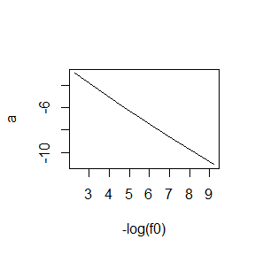

```r
plot(-log(f0), a, type="l")
```

可以看到−log f0 和 a的关系是线性的，a随−log f0增大而递减。

### 9.4

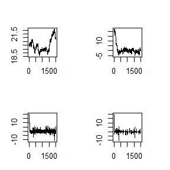

```r
# laplace分布概率密度函数
laplace <- function(x){
  0.5*exp(-abs(x))
}

# random walk metropolis 采样
rw.Metropolis <- function(sigma, x0, N) {
  x <- numeric(N)
  x[1] <- x0  # markov chain的第一个值
  u <- runif(N)
  k <- 0
  for (i in 2:N) {
    y <- rnorm(1, x[i-1], sigma)
    if (u[i] <= (laplace(y) / laplace(x[i-1]))){ # 接受
      x[i] <- y
    } else { # 拒绝
      x[i] <- x[i-1]
      k <- k + 1
    }
  }
  return(list(x=x, k=k))
}

N <- 2000 # 迭代步数
sigma <- c(.05, .5, 2, 16) # 方差
x0 <- 20 # markov chain的第一个值
rw1 <- rw.Metropolis(sigma[1], x0, N)
rw2 <- rw.Metropolis(sigma[2], x0, N)
rw3 <- rw.Metropolis(sigma[3], x0, N)
rw4 <- rw.Metropolis(sigma[4], x0, N)

index = 1:2000
par(mar = c(3, 3, 3, 3))
par(mfrow=c(2,2))
plot(index, rw1$x, type="l", xlab="sigma=.05", ylab="x")
plot(index, rw2$x, type="l", xlab="sigma=.5", ylab="x")
plot(index, rw3$x, type="l", xlab="sigma=2", ylab="x")
plot(index, rw4$x, type="l", xlab="sigma=16", ylab="x")
```

上面分别是是$\sigma$取0.05,0.5, 2,16得到的Markov Chain的迭代值。可以看到，当$\sigma=0.05$时，Markov Chain收敛非常慢，在2000步内没有收敛。随着$\sigma$增大，收敛速度变快。但是当$\sigma=16$时，出现大量连续的重复值。

下面计算各个$\sigma$取值下的接受率，

```r
accptance = numeric(4)
accptance[1] <- 1-rw1$k/N
accptance[2] <- 1-rw2$k/N
accptance[3] <- 1-rw3$k/N
accptance[4] <- 1-rw4$k/N
table.accptance = data.frame(sigma = sigma, apptance.rate = accptance)
table.accptance
```

```
##   sigma apptance.rate
## 1  0.05        0.9815
## 2  0.50        0.8465
## 3  2.00        0.5105
## 4 16.00        0.0945
```

可以看到，$\sigma$越大，接受率越低。

### 9.7

```r
# 初始化参数
N <- 5000 # markov chain的长度
burn <- 1000 # burn-in 长度
X <- matrix(0, N, 2) # 记录markov chain
rho <- 0.9 # 相关系数
mu1 <- 0 # 均值
mu2 <- 0
sigma1 <- 1 # 方差
sigma2 <- 1
s1 <- sqrt(1-rho^2)*sigma1 # 边缘分布的方差
s2 <- sqrt(1-rho^2)*sigma2

X[1, ] <- c(mu1, mu2) # 初始化
for (i in 2:N) {
  x2 <- X[i-1, 2]
  m1 <- mu1 + rho * (x2 - mu2) * sigma1/sigma2
  X[i, 1] <- rnorm(1, m1, s1)
  x1 <- X[i, 1]
  m2 <- mu2 + rho * (x1 - mu1) * sigma2/sigma1
  X[i, 2] <- rnorm(1, m2, s2)
}
b <- burn + 1
x <- X[b:N, ] # 去除burn-in部分的markov chain
```

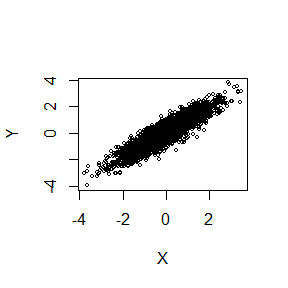

```r
plot(x, main="", cex=.5, xlab=bquote(X), ylab=bquote(Y), ylim=range(x[,2]))
```

```r
model <- lm(x[, 2]~x[, 1])
summary(model)
```

```
##
## Call:
## lm(formula = x[, 2] ~ x[, 1])
##
## Residuals:
##      Min       1Q   Median       3Q      Max
## -1.66840 -0.29130 -0.00481  0.29158  1.48835
##
## Coefficients:
##              Estimate Std. Error t value Pr(>|t|)
## (Intercept) -0.004543   0.006848  -0.663    0.507
## x[, 1]       0.899988   0.006772 132.893   <2e-16 ***
## ---
## Signif. codes:  0 '***' 0.001 '**' 0.01 '*' 0.05 '.' 0.1 ' ' 1
##
## Residual standard error: 0.4329 on 3998 degrees of freedom
## Multiple R-squared:  0.8154, Adjusted R-squared:  0.8154
## F-statistic: 1.766e+04 on 1 and 3998 DF,  p-value: < 2.2e-16
```

```r
shapiro.test(model$residuals)
```

```
##
##  Shapiro-Wilk normality test
##
## data:  model$residuals
## W = 0.99954, p-value = 0.4865
```

在置信水平为0.05的情况下，不拒绝正态性假设，残差是服从正态分布的。

```r
se <- sd(model$residuals)
se
```

```
## [1] 0.4328728
```

残差的标准差为0.4328728。

### 9.10

```r
# 目标分布
f <- function(x, sigma) {
  if (any(x < 0)) { # 定义域x大于0
    return (0)
  }
  stopifnot(sigma > 0) # sigma需要大于0
  return((x / sigma^2) * exp(-x^2 / (2*sigma^2)))
}

# Gelman.Rubin方法
Gelman.Rubin <- function(psi) {
  psi <- as.matrix(psi) # psi是markov chain的统计量
  n <- ncol(psi)
  k <- nrow(psi)
  psi.means <- rowMeans(psi) #行均值
  B <- n * var(psi.means) #between variance est.
  psi.w <- apply(psi, 1, "var") #within variances
  W <- mean(psi.w) #within est.
  v.hat <- W*(n-1)/n + (B/n) #方差的上界
  r.hat <- v.hat / W #G-R 统计量
  return(r.hat)
}

# 参数
sigma <- .2 # 提议分布的参数
k <- 4 #chain的数量
b <- 1000 #burn-in长度

#生成初始值
set.seed(123)
x0 <- rchisq(k, df=1)

X <- matrix(x0) # 记录markov chain
psi <- matrix(x0) # 记录统计量
R.hat <- 2 # 初始化R.hat，使其大于1.2

i = 2 # chain的长度
while (R.hat >= 1.2) { # 循环直到R.hat大于1.2，实现了控制
  xt <- X[, i-1]
  y <- rchisq(k, df = xt)
  r1 <- f(y, sigma) * dchisq(xt, df = y)
  r2 <- f(xt, sigma) * dchisq(y, df = xt)
  flag <- runif(4) <= r1/r2 # 这里flag用来表示时候接受提议分布
  X <- cbind(X, flag*y+(1-flag)*xt) # 将拒绝或接受的值加入
  psi <- cbind(psi, psi[, i-1]+(X[, i]-psi[, i-1])/i) # 更新统计量
  R.hat <- Gelman.Rubin(psi)
  i = i + 1
}

print(R.hat)
```

```
## [1] 1.19997
```

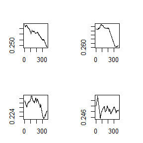

```r
n = ncol(psi)

#画chain
par(mar = c(3, 3, 3, 3))
par(mfrow=c(2,2))
for (i in 1:k)
  plot(psi[i, (b+1):n], type="l", xlab=i, ylab=bquote(psi))
```

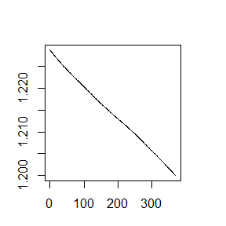

```r
par(mfrow=c(1,1)) #restore default

#画R-hat statistics
rhat <- rep(0, n)
for (j in (b+1):n)
  rhat[j] <- Gelman.Rubin(psi[,1:j])
plot(rhat[(b+1):n], type="l", xlab="", ylab="R")
abline(h=1.1, lty=2)
```

上面在$R.hat<1.2$时停止了迭代，下面使用coda包来检验生成的Markov Chain是否收敛。

```r
library(coda)

mcmclist <- mcmc.list(mcmc(X[1, ]), mcmc(X[2, ]), mcmc(X[3, ]), mcmc(X[4, ]))
gelman.diag(mcmclist)
```

```
## Potential scale reduction factors:
##
##      Point est. Upper C.I.
## [1,]       1.01       1.02
```

可以看到点估计量为1，0.95的置信区间上界为1，可以认为Markov Chain已经收敛。

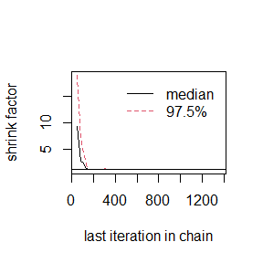

```r
gelman.plot(mcmclist)
```

# 2023/11/13

## Question

1.设$X_1, \ldots, X_n \overset{iid}{\sim}Exp(\lambda)$。因为某些原因，只知$X_i$落在某个区间$(u_i, v_i)$，其中$u_i < v_i$是两个非随机的已知常数。这种数据称为区间删失数据。

(1)尝试分别直接极大化观测数据的似然函数与采用EM算法求解$\lambda$的MLE，证明EM算法收敛于观测数据的MLE，且收敛有线性速度。

(2)设$(u_i, v_i),i = 1,\ldots,n(=10)$的观测值为$(11,12),(8,9),(27,28),(13,14),(16,17),(0,1),(23,24),(10,11),(24,25),(2,3)$。试分别编成实现上述两种算法以得到$\lambda$的MLE的数值解。

提示：观测数据的似然函数为$L(\lambda)=\prod_{i=1}^{n}P_r(u_i \leq X_i \leq v_i)$ 。

2.Exercises 11.8 (pages 354, Statistical Computing with R).

## Answer

### 1

（1）

MLE：

似然函数为

$$L(\lambda) = \prod_{i=1}^{n}P_{\lambda}( u_i \leq X_i \leq
v_i)=\prod_{i=1}^{n}(e^{-\lambda u_i}-e^{-\lambda v_i}),$$

对数似然函数为

$$l(\lambda) = \sum_{i=1}^{n} \log(e^{-\lambda u_i}-e^{-\lambda v_i}).$$

当满足

$$\frac{\partial l(\lambda)}{\partial \lambda} = \sum_{i=1}^{n} \frac{-u_i
e^{-\lambda u_i}+ v_i e^{-\lambda v_i}}{e^{-\lambda u_i}-e^{-\lambda
v_i}}=0,$$

此时的$\lambda ^*$为MLE。

EM：

变量$X_i$的观测值$x_i$是未知的，在观测值为$x_i$时的似然函数为

$$L(\lambda|X_i) = \prod_{i=1}^{n} \lambda e^{-\lambda x_i}=\lambda^n
\prod_{i=1}^{n} e^{-\lambda x_i}.$$

对数似然函数为

$$l(\lambda|X_i) = n \log{\lambda} - \lambda \sum_{i=1}^{n}x_i.$$

在已知$u_i, v_i$的情况下

$$
$$\begin{aligned}
E[X_i|u_i,v_i] &= \int_{u_i}^{v_i} x_i \frac{\lambda e^{-\lambda
x_i}}{\int_{u_i}^{v_i}\lambda e^{-\lambda x_i}d x_i} d x_i \\
&= \frac{u_i e^{-\lambda u_i}- v_i e^{-\lambda v_i}}{e^{-\lambda
u_i}-e^{-\lambda v_i}} + \frac{1}{\lambda} .
\end{aligned}$$

E步：

$$E_{\lambda_0}[l(\lambda|X_i) | u_i, v_i] = n \log \lambda -\lambda
\sum_{i=1}^{n}E_{\lambda_0}[X_i|u_i,v_i].$$

M步：

$$\frac{\partial E_{\lambda_0}[l(\lambda|X_i) | u_i, v_i]}{\partial
\lambda} = \frac{n}{\lambda} -
\sum_{i=1}^{n}E_{\lambda_0}[X_i|u_i,v_i]=0.$$

得到

$$\lambda_1 = \frac{n}{\sum_{i=1}^{n}E_{\lambda_0}[X_i|u_i,v_i]},$$

由此可以得到EM算法的迭代格式

$$\lambda_{t+1} = \frac{1}{\frac{1}{n}\sum_{i=1}^{n}\frac{u_i
e^{-\lambda_{t} u_i}- v_i e^{-\lambda_{t} v_i}}{e^{-\lambda_{t}
u_i}-e^{-\lambda_{t} v_i}} + \frac{1}{\lambda_{t}}}.$$

可以简单验证得到，当EM算法收敛时，将MEL $\lambda^*$带入EM算法，

$$\frac{1}{\frac{1}{n}\sum_{i=1}^{n}\frac{u_i e^{-\lambda_* u_i}- v_i
e^{-\lambda_* v_i}}{e^{-\lambda_* u_i}-e^{-\lambda_* v_i}} +
\frac{1}{\lambda_*}} = \frac{1}{\frac{1}{\lambda^*}} =\lambda^* .$$

因此EM算法收敛时的解就是MLE。

下证EM算法的收敛性。

证明.

令迭代函数为

$$f(\lambda) = \frac{1}{\frac{1}{n}\sum_{i=1}^{n}\frac{u_i e^{-\lambda
u_i}- v_i e^{-\lambda v_i}}{e^{-\lambda u_i}-e^{-\lambda v_i}} +
\frac{1}{\lambda}}.$$

再令

$$q(\lambda) = \sum_{i=1}^{n}\frac{u_i e^{-\lambda u_i}- v_i e^{-\lambda
v_i}}{e^{-\lambda u_i}-e^{-\lambda v_i}}, \\
q(\lambda^*) = 0.$$

$\lambda^*$是$f(\lambda)$的一个不动点。

下证$0 < f'(\lambda^*) < 1$。

$$f'(\lambda) =
-\frac{1}{(\frac{1}{n}q(\lambda)+\frac{1}{\lambda})^2}(\frac{1}{n}q'(\lambda)-\frac{1}{\lambda^2}),$$

$$\begin{aligned}
f'(\lambda^*) &= 1-\frac{1}{n}\lambda^{*2}q'(\lambda^*)\\
&=1-
\frac{1}{n}\sum_{i=1}^n\frac{(u_i-v_i)^2\lambda^{*2}}{-2+e^{\lambda^*(v_i-u_i)}+e^{\lambda^*(u_i-v_i)}}.
\end{aligned}$$

令$d_i = (v_i - u_i)\lambda^* > 0$,

泰勒展开

$$0 < f'(\lambda^*) < 1,$$

因此$f(\lambda)$线性收敛于$\lambda^*$。

（2）

先使用极大似然法

```r
u <- c(11, 8, 27, 13, 16, 0, 23, 10, 24, 2)
v <- c(12, 9, 28, 14, 17, 1, 24, 11, 25, 3)
mlogL <- function(lambda) {
    # minus log-likelihood
    return(sum(log(exp(-lambda*u)-exp(-lambda*v))))
}

res <- optimize(mlogL, lower=0, upper=10, maximum=TRUE)
res$maximum
```

```
## [1] 0.07198597
```

接下来使用EM算法

```r
u <- c(11, 8, 27, 13, 16, 0, 23, 10, 24, 2)
v <- c(12, 9, 28, 14, 17, 1, 24, 11, 25, 3)

# EM算法的迭代函数
f <- function(lambda) {
    1/mean(((-v-1/lambda)*exp(-lambda*v)+(u+1/lambda)*exp(-lambda*u))/(exp(-lambda*u)-exp(-lambda*v)))
}

loss <- 1 # 前后两次迭代的差
t <- 1 # 迭代次数

lambda <- 0.1
while (t<1000 & loss>1e-8) { # 迭代次数大于1000或误差小于1e-8时停止迭代
    lambda1 <- lambda
    lambda <- f(lambda)
    loss <- abs(lambda - lambda1)
    t = t + 1
}
lambda
```

```
## [1] 0.0719735
```

可以看到，两种方法得到的结果十分相近。

### 2

```r
solve.game <- function(A) {
    #solve the two player zero-sum game by simplex method
    #optimize for player 1, then player 2
    #maximize v subject to ...
    #let x strategies 1:m, and put v as extra variable
    #A1, the <= constraints
    #
    min.A <- min(A)
    A <- A - min.A #so that v >= 0
    max.A <- max(A)
    A <- A / max(A)
    m <- nrow(A)
    n <- ncol(A)
    it <- n^3
    a <- c(rep(0, m), 1) #objective function
    A1 <- -cbind(t(A), rep(-1, n)) #constraints <=
    b1 <- rep(0, n)
    A3 <- t(as.matrix(c(rep(1, m), 0))) #constraints sum(x)=1
    b3 <- 1
    sx <- simplex(a=a, A1=A1, b1=b1, A3=A3, b3=b3,
        maxi=TRUE, n.iter=it)
    #the ’solution’ is [x1,x2,...,xm | value of game]
    #
    #minimize v subject to ...
    #let y strategies 1:n, with v as extra variable
    a <- c(rep(0, n), 1) #objective function
    A1 <- cbind(A, rep(-1, m)) #constraints <=
    b1 <- rep(0, m)
    A3 <- t(as.matrix(c(rep(1, n), 0))) #constraints sum(y)=1
    b3 <- 1
    sy <- simplex(a=a, A1=A1, b1=b1, A3=A3, b3=b3,
        maxi=FALSE, n.iter=it)
    soln <- list("A" = A * max.A + min.A,
        "x" = sx$soln[1:m],
        "y" = sy$soln[1:n],
        "v" = sx$soln[m+1] * max.A + min.A)
    soln
}
```

```r
#enter the payoff matrix
A <- matrix(c(  0,-2,-2,3,0,0,4,0,0,
                2,0,0,0,-3,-3,4,0,0,
                2,0,0,3,0,0,0,-4,-4,
                -3,0,-3,0,4,0,0,5,0,
                0,3,0,-4,0,-4,0,5,0,
                0,3,0,0,4,0,-5,0,-5,
                -4,-4,0,0,0,5,0,0,6,
                0,0,4,-5,-5,0,0,0,6,
                0,0,4,0,0,5,-6,-6,0), 9, 9)
library(boot) #needed for simplex function
s <- solve.game(A)
```

```r
round(cbind(s$x, s$y), 7)
```

```
##         [,1]      [,2]
## x1 0.0000000 0.0000000
## x2 0.0000000 0.0000000
## x3 0.4098361 0.4098361
## x4 0.0000000 0.0000000
## x5 0.3278689 0.3278689
## x6 0.0000000 0.0000000
## x7 0.2622951 0.2622951
## x8 0.0000000 0.0000000
## x9 0.0000000 0.0000000
```

```r
B <- A + 2
s1 <- solve.game(B)
round(cbind(s1$x, s1$y), 7)
```

```
##         [,1]      [,2]
## x1 0.0000000 0.0000000
## x2 0.0000000 0.0000000
## x3 0.4098361 0.4098361
## x4 0.0000000 0.0000000
## x5 0.3278689 0.3278689
## x6 0.0000000 0.0000000
## x7 0.2622951 0.2622951
## x8 0.0000000 0.0000000
## x9 0.0000000 0.0000000
```

```r
cat("A: ", s$v)
```

```
## A:  0
```

```r
cat("B: ", s1$v)
```

```
## B:  2
```

游戏A的价值是0，游戏2的价值是2。

# 2023/11/20

## Question

- 2.1.3 Exercise 4 (Pages 19 Advanced in R)
- 2.3.1 Exercise 1, 2 (Pages 26 Advanced in R)
- 2.4.5 Exercise 2, 3 (Pages 30 Advanced in R)
- Exercises 2 (page 204, Advanced R)
- Exercises 1 (page 213, Advanced R)
2. Consider Exercise 9.8 (pages 278, Statistical Computing with R). (Hint: Refer to the first example of Case studies section)
- Write an R function.
- Write an Rcpp function.
- Compare the computation time of the two functions with the function “microbenchmark”

## Answer

### 2.1.3 Exercise 4

`unlist()`可以将列表展平成为向量；`as.vector()`不会将列表展平，当列表有嵌套结构时，`as.vector()`可能无法产生期望的结果。

```r
x <- list(a = 1, b = list(c = 2, d = 3))
unlist(x)
```

```
##   a b.c b.d
##   1   2   3
```

```r
as.vector(x)
```

```
## $a
## [1] 1
##
## $b
## $b$c
## [1] 2
##
## $b$d
## [1] 3
```

### 2.3.1 Exercise 1

将会返回NULL，向量没有维度概念。

```r
a <- c(1, 2, 3)
dim(a)
```

[output not shown]

### 2.3.1 Exercise 2

`is.array(x)`的结果也是TRUE，因为matrix是始终特殊的array。

```r
x <- matrix(data = 1:6, nrow = 2, ncol = 3)
is.matrix(x)
```

```
## [1] TRUE
```

```r
is.array(x)
```

```
## [1] TRUE
```

### 2.4.5 Exercise 2

`as.matrix()`会将所有数据转换为同一类型，转换结果遵循R中的规则。

```r
x <- data.frame(
    numeric_col = c(1, 2, 3),
    character_col = c("a", "b", "c"),
    logical_col = c(TRUE, FALSE, TRUE)
)

as.matrix(x)
```

```
##      numeric_col character_col logical_col
## [1,] "1"         "a"           "TRUE"
## [2,] "2"         "b"           "FALSE"
## [3,] "3"         "c"           "TRUE"
```

### 2.4.5 Exercise 3

0行的dataframe可以实现。

```r
x1 <- data.frame(matrix(nrow = 0, ncol = 3))
x1
```

```
## [1] X1 X2 X3
## <0 rows> (or 0-length row.names)
```

0列的dataframe也可以实现。

```r
x2 <- data.frame(matrix(nrow = 3, ncol = 0))
x2
```

```
## data frame with 0 columns and 3 rows
```

### Exercises 2（204）

运用到所有列。

```r
scale01 <- function(x) {
    rng <- range(x, na.rm = TRUE)
    (x - rng[1]) / (rng[2] - rng[1])
}

x <- data.frame(
    a = 1:3,
    b = 7:9,
    c = 4:6
)

lapply(x, scale01)
```

```
## $a
## [1] 0.0 0.5 1.0
##
## $b
## [1] 0.0 0.5 1.0
##
## $c
## [1] 0.0 0.5 1.0
```

运用到数值列。

```r
y <- data.frame(
    a = 1:3,
    b = c('q', 'w', 'e'),
    c = 4:6
)

lapply(y, function(x) {if (is.numeric(x)) scale01(x) else x})
```

```
## $a
## [1] 0.0 0.5 1.0
##
## $b
## [1] "q" "w" "e"
##
## $c
## [1] 0.0 0.5 1.0
```

### Exercises 1（213）

运用到所有列。

```r
x <- data.frame(
    a = 1:3,
    b = 7:9,
    c = 4:6
)

vapply(x, sd, numeric(1))
```

```
## a b c
## 1 1 1
```

运用到数值列。

```r
y <- data.frame(
    a = 1:3,
    b = c('q', 'w', 'e'),
    c = 4:6
)

vapply(y[vapply(y, is.numeric, logical(1))], sd, numeric(1))
```

```
## a c
## 1 1
```

### Exercise 9.8

R function

```r
#initialize constants and parameters
N <- 50000 #length of chain
burn <- 1000 #burn-in length

n <- 10
a <- 2
b <- 3

gibbsR <- function(N, burn, n, a, b){
    x1 <- 3
    y1 <- 0.5
    X <- matrix(0, N, 2) #the chain, a bivariate sample
    X[1, ] <- c(x1, y1)

    for (i in 2:N) {
        yt <- X[i-1, 2]
        X[i, 1] <- rbinom(1, n, yt)
        xt <- X[i, 1]
        X[i, 2] <- rbeta(1, xt + a, n - xt + b)
    }
    X
}
```

```r
library(Rcpp)
library(microbenchmark)

# dir_cpp <- "./"
# sourceCpp(paste0(dir_cpp, "gibbsC.cpp"))

cppFunction('NumericMatrix gibbsC(int N, int burn, int n, int a, int b) {
    int x1 = 3;
    double y1 = 0.5;
    NumericMatrix X(N, 2);
    X(0, 0) = x1;
    X(0, 1) = y1;

    int xt = x1;
    double yt = y1;
    for (int i = 1; i < N; i++) {
        yt = X(i-1, 1);
        X(i, 0) = R::rbinom(n, yt);
        xt = X(i, 0);
        X(i, 1) = R::rbeta(xt + a, n - xt + b);
    }

    return X;
}')

ts <- microbenchmark(gibbsR=gibbsR(N, burn, n, a, b), gibbsC=gibbsC(N, burn, n, a, b))
summary(ts)[,c(1,3,5,6)]
```

```
##     expr       lq   median       uq
## 1 gibbsR 102.6770 103.5105 104.8831
## 2 gibbsC   7.9453   7.9940   8.0931
```

可以看到使用Rcpp的运行时间比直接使用R function的时间短很多。